# 数据分析岗位分析

```python
import pandas as pd
boss = pd.read_csv('./data/boss岗位.csv')
boss .head(2)
```

|  | 标题 | 地区 | 公司名 | 公司领域 | 薪资 | 经验 | 规模 | 福利 | 详情页 |
| --- | --- | --- | --- | --- | --- | --- | --- | --- | --- |
| 0 | 数据分析师 | 北京·海淀区·公主坟 | 锐捷网络 | 通信/网络设备 | 20-30K·13薪 | 3-5年本科 | 1000-9999人 | 通讯补贴，节日福利，五险一金，定期体检，带薪年假，餐补，包吃，加班补助，员工旅游，零食下午茶... | https://www.zhipin.com/job_detail/42975c4fd5ea... |
| 1 | 数据分析师 | 上海·浦东新区·张江 | 中电金信 | 计算机软件 | 15-25K | 经验不限本科 | 10000人以上 | 定期体检，节日福利，五险一金，补充医疗保险，带薪年假，零食下午茶 | https://www.zhipin.com/job_detail/3f9754994eb4... |

```python
boss.info()
```

```
<class 'pandas.core.frame.DataFrame'>
RangeIndex: 2913 entries, 0 to 2912
Data columns (total 9 columns):
 #   Column  Non-Null Count  Dtype
---  ------  --------------  -----
 0   标题      2913 non-null   object
 1   地区      2913 non-null   object
 2   公司名     2913 non-null   object
 3   公司领域    2913 non-null   object
 4   薪资      2913 non-null   object
 5   经验      2913 non-null   object
 6   规模      2913 non-null   object
 7   福利      2531 non-null   object
 8   详情页     2913 non-null   object
dtypes: object(9)
memory usage: 204.9+ KB
```

```python
boss[boss['标题'].str.contains('数据分析') ] ['标题'].unique()
```

```
array(['数据分析师', '数据分析', '高级数据分析师', '数据分析师 (MJ000122)', 'SCG-数据分析师',
       '大气数据分析师', '数据分析师BI', '高级数据分析师（电商）', '数据分析专家', '资深数据分析师',
       '数据分析师（经理）', '数据分析师-北京', '数据分析助理', '数据分析主管', '数据分析师（商业分析方向）',
       '数据分析专员', '数据分析师-价格', '数据分析经理/总监', '高级数据分析运营', '数据分析工程师',
       '数据分析师（商品）', '数据分析师（四轮业务）', '高级数据分析工程师', '专家级数据分析师', '数据分析师（可实习)',
       '数据分析师(J10176)', '数据分析师（距离番禺25分钟车程）', '数据分析师（餐饮业）', '策略数据分析师',
       '数据分析（Python）', '【2022校招】数据分析', '广告运营（数据分析）', '数据分析 双休+五险一金+13薪',
       '数据分析工程师(AI骨科)', '数据分析师（毕节）', '抖音电商 - 资深数据分析师【内推】', 'Python数据分析师',
       '工业数据分析师', '数据分析师（市场调研分析）', '数据分析师（数据管理方向）', 'Python数据分析师助理',
       'AI算法工程师（数据分析）', '产品规划数据分析专员', '数据分析实习生', '数据分析-广州', '数据分析经理',
       '大学在线教育高级数据分析师', '数据分析岗(J12323)', '资深数据分析师-广告投放变现数据',
       '数据分析师 （偏大数据开发、挖掘方向）', '数据分析经理(J10345)', '游戏平台数据分析师', '数据分析师（宁波）',
       '资深数据分析专家', '软件开发工程师-数据分析', '生物信息数据分析', '（高级）数据分析师',
       '抖音电商 - 数据分析师（产品分析）', '视频数据分析师 (MJ000205)', '数据分析工程师（腾讯全资子公司）',
       '中高级数据分析师', '业务数据分析专家/数据分析师 阿里P7', '人力资源（数据分析方向）', '腾讯长视频标签数据分析',
       '《王者荣耀》数据分析（腾娱互动）', '高级数据分析师-数据科学中台', '爬虫数据分析师', '数据分析师（爬虫）',
       '数据分析实习生（python方向）', '双休+DBA /大数据分析+五险一金', '大数据分析与开发',
       '数据分析师（数据挖掘）', '数据分析员（财务）', '大数据分析与挖掘工程师', '数据分析研究员',
       'Sr. Data Analyst 资深数据分析师', '广告投放及数据分析管培生', '数据分析员', '高级数据分析专员',
       '数据分析员（南京）', '市场企划专员（数据分析方向）', '充电桩运营数据分析员', '业务数据分析',
       '高级数据分析师（物流）', '数据分析与挖掘工程师', 'Data Analyst 数据分析师 (MJ002379)',
       '腾讯云-AI平台机器学习数据分析工程师'], dtype=object)
```

```python
boss[boss['标题'].str.contains('开发')]['标题'].unique()
```

```
array(['数据分析师 （偏大数据开发、挖掘方向）', '软件开发工程师-数据分析', '爬虫开发工程师', 'Python爬虫开发工程师',
       'Python爬虫/反爬开发实习（可转正）', 'Python爬虫开发', '爬虫开发',
       '跨境电商-数据采集同步-爬虫Python开发', 'python爬虫开发工程师', '爬虫开发工程师(J10550)',
       '爬虫开发（非python）', 'Python开发', 'python开发实习生', 'Python开发工程师',
       'Python开发工程师（实习）', 'python web 开发工程师', 'python后端开发工程师',
       'python开发工程师', 'python Web开发工程师', 'python服务端开发', 'python实施开发工程师',
       'Python开发实习生', '百度python开发', 'Python嵌入式软件开发', 'python开发',
       'Python后端开发工程师', 'python开发工程师（RPA技术方向）', 'Python开发工程师（兼职）',
       'python 后台开发工程师', 'Python初级开发工程师', 'PYTHON开发', '大数据开发',
       'BI\\大数据技术开发-应届生-全职', '大数据开发讲师', '大数据开发工程师', '大数据开发工程师（中银）',
       '大数据开发专家', '大数据开发实习生', '大数据开发工程师（Hadoop）', '大数据开发（工商银行）',
       '大数据开发经理', '大数据高级开发工程师', '大数据开发工程师（接受应届生，python）',
       '大数据开发工程师 (MJ000563)', '高级大数据开发工程师', '大数据开发工程师 22届校招', '大数据平台开发',
       '大数据开发专家 (MJ000749)', '大数据分析与开发', '大数据开发管培生', '大数据开发工程师（校招）',
       '大数据平台开发工程师', '大数据开发（北京）', '大数据开发【2022届校招】', '中级大数据开发工程师',
       '大数据Go开发工程师 (MJ000094)', '软件开发大数据实习生', '大数据开发工程师实习生-0908',
       '大数据开发（南宁）', '大数据开发（提供住宿，有补助）', '大数据开发工程师（新疆昌吉）', '高级大数据开发',
       '数据库开发', '数据开发', '数据库开发工程师（2022） (MJ000171)', '数据仓库开发',
       '数据开发高级工程师', '高级大数据开发工程师(J10086)', '大数据开发/BI工程师', 'Java开发工程师',
       'NoSQL数据库开发工程师', 'GO开发工程师 双休+早九晚六+包两餐+班车',
       'Android开发工程师（线上面试，项目优质）', '人工智能开发工程师（图像方向实习）', '人工智能开发工程师',
       '软件开发工程师（人工智能方向）', '人工智能应用开发工程师', '人工智能场景-服务开发工程师(java)',
       'U3D实习生 游戏开发 人工智能', '浪潮人工智能研究院-固件开发工程师', '人工智能方向开发人员',
       '人工智能--C++开发工程师', '人工智能开发(大数据)', '后端开发工程师', '后端开发',
       '后端开发实习生（PHP/Python)', 'node.js后端开发工程师', '后端开发netcore', '后端开发实习生',
       '前端开发', 'PHP后端开发', 'nodejs后端开发工程师', '前端开发实习生-有转正机会', '游戏后端开发',
       'Java后端开发', 'java后端开发（初级）', '后端开发工程师 （初级）', 'Java后端开发工程师',
       '【22届校招】Web前端开发工程师', '后端开发工程师（22届校招）', 'php后端开发',
       'Node.js开发实习生（店客多）', '软件研发后端开发', 'Node后端开发工程师', 'java后端开发',
       'Golang 后端开发工程师', 'Node.js服务器开发工程师', 'node.js后端开发', '.NET后端开发工程师',
       'Python后端开发', '前端开发工程师', '.net/.net core 后端开发', '中级前端开发工程师',
       'Golang后端开发工程师', '后端开发.net、小程序', '软件开发技术', 'JAVA后端开发',
       '后端开发/JAVA 实习生/应届生', '资深前端开发工程师', '开发工程师', '高级后端开发工程师',
       '后端开发工程师（管培生）', '高级Java后端开发工程师', '前端开发工程师（2022届）',
       'JAVA后端开发--岗位双休', '高级后端开发', '高级前端开发', '云平台后端开发工程师', 'PHP后端开发工程师',
       '电商网络开发', 'IT后端开发类Java/PHP/Golang--2022届', '移动端开发', 'Java后端开发实习生',
       '后端开发Java', '后端开发（南瑞大厦）', '后端高级开发', '后端开发工程师（go/golang）',
       'JAVA后端开发工程师', '淘系前端开发——校招', '软件开发工程师', '.NET高级开发工程师（上位机/自动化方向）',
       '资深后端定位开发工程师', 'Java开发工程师_ZH_91542_00015', '后端开发/主管',
       '中高级Java后端开发工程师', '软件后端开发工程师', '计量计费后端开发架构', '高级后端开发工程师/技术架构师',
```

[output cut: 9 more lines]

```
       '安卓app/android开发（大专应届都可，急）', '前端开发实习生-飞书',
       'Java开发工程师（双休/政府项目/电话面试）', 'Java开发（试用期全薪 大厂 双休 加班少）', 'web开发',
       'Web开发', 'Web前端开发', 'web前端开发工程师', 'WEB前端开发', 'Web前端开发工程师',
       'WEB前端软件开发', 'web前端开发', 'WEB前端开发实习生', 'WEB前端开发工程师', 'WEB开发工程师（急）',
       '实习web开发工程师-2022届', 'Web前端开发工程师(应届)', 'web前端开发实习生', 'web开发程序员',
       'web开发工程师', 'Web前端开发Vue方向在廊坊开发区', '前端web开发（精通Vue框架）', '字节前端开发',
       'Web开发工程师', '高级Web前端开发', '急聘web 前端开发工程师', 'web3.js开发工程师',
       '移动web前端开发', 'WEB开发工程师', 'WEB前端开发工程师-初级', '前端web开发',
       'Web开发工程师（武汉s）', 'java/web开发', 'Web前端开发工程师（Vue/自研产品）',
       '高级web开发工程师', '中高级Web前端开发工程师', '前端开发工程师（北京项目） (MJ006119)',
       '前端开发/H5', '前端开发周末双休', '后端开发、机器学习算法实习生', '数据风控开发',
       '后端开发（机器学习和数据搭建）', 'AI 算子测试开发', '腾讯地图Android高级开发工程师-外派腾讯',
       '中高级python开发工程师（ 自研 五险一金）', '深度学习算法开发工程师', 'Linux C++开发专家',
       '高级/资深Java开发工程师-电商方向', '后端开发工程师-AML机器学习平台', 'Java中高级开发工程师',
       '机器学习后端开发工程师'], dtype=object)
```

```python
boss[(~boss['标题'].str.contains('开发'))& (~boss['标题'].str.contains('人工智能')) & (~boss['标题'].str.contains('数据分析'))& (~boss['标题'].str.contains('爬虫'))& (~boss['标题'].str.contains('运维'))& (~boss['标题'].str.contains('大数据'))& (~boss['标题'].str.contains('测试'))& (~boss['标题'].str.contains('数据挖掘'))& (~boss['标题'].str.contains('机器学习'))& (~boss['标题'].str.contains('深度学习'))& (~boss['标题'].str.contains('数据'))& (~boss['标题'].str.contains('算法'))]['标题'].unique()
```

```
array(['Python', 'python', 'Python工程师', 'Python(校招）', 'Python后端',
       'python助教', 'Python编程老师', 'Python编程教师', 'Python老师', 'python工程师',
       'PYTHON程序员', 'Python少儿编程老师', 'python实习生', 'Python程序员',
       'Python答疑老师（实习）', '研发工程师（实习生)-python', 'python研发工程师',
       'Python软件工程师', 'C/C++/python实习生', 'Python讲师', 'Python实习',
       'Python后端研发', 'python少儿编程老师（陈村）', 'Python实习生', 'Python教师',
       'Python实习工程师', '蓝月亮招聘仓库文员', 'BI工程师', '后端实习生', '后端工程师',
       'JAVA软件工程师+六险一金+包食宿', '后端研发实习生', 'web前端', 'web前端实习生', 'web',
       'Web前端', '移动web前端', 'WEB工程师', 'web前端工程师', 'WEB前端工程师', 'WEB前端工程',
       'web 前端', '前端高级工程师', 'web前端（北京）', '机器视觉', '计算机视觉实习生', '机器人学习研究员',
       '机器人工程师', '机器人', '机器人调试', '中高级Java(双休+3年+14k以上+线上面试)', 'AI工程师',
       '机器视觉工程师', '标注专员', '机器人创客老师', 'CNC/数控', '学习规划师', '学习顾问', '学习管理师',
       '文本模型训练师', '工业机器人应用工程师', '计算机视觉博士研究员', '学习官', '医学图像分析资深专家(J11742)',
       '软件工程师', '工作地武隆/中医助理/4K-6K+学习机会', '机器视觉技术支持工程师', '机器人调试工程师',
       '朝九晚六双休后勤无经验可学习', '机器人OP岗', 'PCB Layout工程师', '英语学习教练', '城东带薪学习祛斑师',
       '机器视觉工程师助理', 'Java研发工程师 (MJ000874)', '在线学习服务师', '家庭学习顾问',
       '实习-AI应用工程师', '机器人应用工程师（实习生）', '机器视觉实习生（2022届）',
       'FPGA 工程师（输配电技术中心）', '机器人应用工程师', '学习规划师-火炬/双休/五险一金', '德阳学习管理师',
       '设计师助理带薪学习＋免费住宿', '计算光刻研发工程师', '学习规划师（年终奖/包住/晋升）', '运营专员（带薪学习技能）',
       '上市公司 新房咨询师[房产客服] 年薪资15W+', '机器人自动化工程师（校招）',
       '到店业务运营（大众点评/口碑） (MJ000041)', 'PHP架构师（Magento）', '亚马逊运营（招学徒）带薪学习',
       '调试工程师（校招岗位）', 'AI工程师-计算机视觉', '计算机视觉研究员（ADAS目标跟踪及部署方向', '反作弊策略实习生',
       '手绘3D场景建模-高级 (MJ000129)', '高级java/不查学历/加班少', '标准化研究中心项目组-博士后',
       '线上学习专家', '广告策略工程师', '强化学习研究员 -AI体育方向', '通用智能计算架构研究员',
       '智能可信与隐私计算理论工程师/研究员', '桌面端C++研发工程师-剪映'], dtype=object)
```

岗位处理

```python
boss['job'] = ''
boss.loc[(boss['标题'].str.contains('数据分析')) & (boss['job']==''),'job'] = '数据分析'
boss.loc[(boss['标题'].str.contains('数据挖掘')) & (boss['job']==''),'job'] = '数据挖掘'
boss.loc[(boss['标题'].str.contains('大数据')) & (boss['job']==''),'job'] = '大数据相关'
boss.loc[(boss['标题'].str.contains('数据')) & (boss['job']==''),'job'] = '其他数据相关'
boss.loc[((boss['标题'].str.contains('人工智能'))| (boss['标题'].str.contains('机器学习'))| (boss['标题'].str.contains('深度学习'))) & (boss['job']==''),'job'] = '人工智能'
boss.loc[((boss['标题'].str.contains('开发')) | (boss['标题'].str.contains('前端'))| (boss['标题'].str.contains('后端'))) & (boss['job']==''),'job'] = '开发相关'
boss.loc[(boss['标题'].str.contains('爬虫')) & (boss['job']==''),'job'] = '爬虫相关'
boss.loc[(boss['标题'].str.contains('运维')) & (boss['job']==''),'job'] = '运维相关'
boss.loc[(boss['标题'].str.contains('测试')) & (boss['job']==''),'job'] = '测试相关'
boss.loc[(boss['标题'].str.contains('算法')) & (boss['job']==''),'job'] = '算法相关'
boss.loc[((boss['标题'].str.contains('python')) | (boss['标题'].str.contains('Python'))| (boss['标题'].str.contains('PYTHON'))) & (boss['job']==''),'job'] = 'Python相关'
boss.loc[boss['job']=='','job'] = '其他'
```

```python
boss[boss['job']=='其他']['标题'].unique()
```

```
array(['蓝月亮招聘仓库文员', 'BI工程师', 'JAVA软件工程师+六险一金+包食宿', 'web', 'WEB工程师',
       '机器视觉', '计算机视觉实习生', '机器人学习研究员', '机器人工程师', '机器人', '机器人调试',
       '中高级Java(双休+3年+14k以上+线上面试)', 'AI工程师', '机器视觉工程师', '标注专员', '机器人创客老师',
       'CNC/数控', '学习规划师', '学习顾问', '学习管理师', '文本模型训练师', '工业机器人应用工程师',
       '计算机视觉博士研究员', '学习官', '医学图像分析资深专家(J11742)', '软件工程师',
       '工作地武隆/中医助理/4K-6K+学习机会', '机器视觉技术支持工程师', '机器人调试工程师',
       '朝九晚六双休后勤无经验可学习', '机器人OP岗', 'PCB Layout工程师', '英语学习教练', '城东带薪学习祛斑师',
       '机器视觉工程师助理', 'Java研发工程师 (MJ000874)', '在线学习服务师', '家庭学习顾问',
       '实习-AI应用工程师', '机器人应用工程师（实习生）', '机器视觉实习生（2022届）',
       'FPGA 工程师（输配电技术中心）', '机器人应用工程师', '学习规划师-火炬/双休/五险一金', '德阳学习管理师',
       '设计师助理带薪学习＋免费住宿', '计算光刻研发工程师', '学习规划师（年终奖/包住/晋升）', '运营专员（带薪学习技能）',
       '上市公司 新房咨询师[房产客服] 年薪资15W+', '机器人自动化工程师（校招）',
       '到店业务运营（大众点评/口碑） (MJ000041)', 'PHP架构师（Magento）', '亚马逊运营（招学徒）带薪学习',
       '调试工程师（校招岗位）', 'AI工程师-计算机视觉', '计算机视觉研究员（ADAS目标跟踪及部署方向', '反作弊策略实习生',
       '手绘3D场景建模-高级 (MJ000129)', '高级java/不查学历/加班少', '标准化研究中心项目组-博士后',
       '线上学习专家', '广告策略工程师', '强化学习研究员 -AI体育方向', '通用智能计算架构研究员',
       '智能可信与隐私计算理论工程师/研究员', '桌面端C++研发工程师-剪映'], dtype=object)
```

```python
boss['job'].value_counts()
```

```
开发相关        552
大数据相关       548
人工智能        348
数据分析        323
爬虫相关        193
运维相关        192
Python相关    184
测试相关        179
其他数据相关      144
其他          120
数据挖掘         88
算法相关         42
Name: job, dtype: int64
```

地区处理（保留市）

```python
boss['city']=boss['地区'].apply(lambda x: x.split('·')[0])
boss['city'].unique()
```

```
array(['北京', '上海', '杭州', '佛山', '深圳', '厦门', '广州', '武汉', '湖州', '嘉兴', '郑州',
       '廊坊', '哈尔滨', '重庆', '西宁', '宁波', '长沙', '烟台', '南京', '泉州', '成都', '西安',
       '福州', '沈阳', '温州', '南昌', '天津', '南通', '苏州', '东莞', '石家庄', '海口', '台州',
       '商丘', '临汾', '绍兴', '新乡', '长春', '漯河', '金华', '济南', '呼伦贝尔', '毕节', '昆明',
       '贵阳', '唐山', '安阳', '合肥', '渭南', '焦作', '南宁', '珠海', '洛阳', '绵阳', '莆田',
       '泰安', '临沂', '太原', '聊城', '青岛', '无锡', '十堰', '清远', '大连', '潍坊', '许昌',
       '徐州', '长治', '常州', '连云港', '阜阳', '梅州', '威海', '丽水', '巴音郭楞蒙古自治州', '德阳',
       '营口', '中山', '保定', '沧州', '宝鸡', '上饶', '盘锦', '河源', '滨州', '日照', '桂林',
       '德州', '大同', '岳阳', '惠州', '吕梁', '开封', '九江', '赤峰', '昌吉回族自治州', '运城',
       '张家口', '呼和浩特', '乌鲁木齐', '三亚', '兰州', '白城', '晋城', '宿迁', '西双版纳傣族自治州',
       '漳州', '龙岩', '郴州', '赣州', '吉安', '柳州', '马鞍山', '晋中', '遵义', '盐城', '银川',
       '孝感', '乌兰察布', '濮阳', '镇江', '眉山', '襄阳', '淄博', '扬州', '承德', '南平', '泸州',
       '邢台', '吴忠', '济宁', '亳州', '宿州', '宁德', '南阳', '阳泉', '平顶山', '荆门', '衡阳',
       '株洲', '衡水', '江门', '鹤壁', '阳江', '秦皇岛', '淮南', '邯郸', '湘西土家族苗族自治州',
       '汕头', '包头', '黄冈', '东营', '泰州', '周口', '吉林', '芜湖', '宜春', '信阳',
       '甘孜藏族自治州', '平凉', '武威', '抚州', '昭通', '锦州', '钦州', '商洛', '绥化', '衢州',
       '荆州', '淮北', '蚌埠', '安庆', '阿克苏地区', '新余', '哈密', '韶关', '克孜勒苏柯尔克孜自治州'],
      dtype=object)
```

薪资处理（最低工资、最高工资和薪期）

```python
boss['salary'] = 12
boss['min'] = 0
boss['max'] = 0
boss.loc[boss['薪资'].str.contains('薪'),'salary'] = boss['薪资'].str.replace('薪','').str.split('·')
def myfuc(x):
    try:
        return x[-1]
    except:
        return x
boss['salary'] = boss['salary'].apply(myfuc)
boss.loc[boss['薪资'].str.contains('K'),'min'] = boss['薪资'].str.split('-')
def myfuc2(x):
    try:
        return x[0]
    except:
        return x
boss['min'] = boss['min'].apply(myfuc2).astype(int)*1000
boss.loc[boss['薪资'].str.contains('K'),'max'] = boss['薪资'].str.split('-')
def myfuc3(x):
    try:
        x=x[-1]
        return x.replace('K','').split('·')[0]
    except:
        return x
boss['max']=boss['max'].apply(myfuc3).astype(int)*1000
# 处理天数据
boss.loc[boss['薪资'].str.contains('天'),'min'] = boss['薪资'].str.replace('元/天','').str.split('-')
boss.loc[boss['薪资'].str.contains('天'),'min'] = boss.loc[boss['薪资'].str.contains('天'),'min'].apply(myfuc2).astype(int)*22
boss.loc[boss['薪资'].str.contains('天'),'max'] = boss['薪资'].str.replace('元/天','').str.split('-')
boss.loc[boss['薪资'].str.contains('天'),'max'] = boss.loc[boss['薪资'].str.contains('天'),'max'].apply(myfuc3).astype(int)*22
# 异常处理
boss.loc[boss['薪资'] == '500-1000元/月','min'] = 500
boss.loc[boss['薪资'] == '500-1000元/月','max'] = 1000
boss.loc[boss['薪资'] == '10-20元/时','min'] = 10*8*22
boss.loc[boss['薪资'] == '10-20元/时','max'] = 20*8*22
boss.loc[boss['薪资'] == '5-50元/时','min'] = 5*8*22
boss.loc[boss['薪资'] == '5-50元/时','max'] = 50*8*22
boss['max'] = boss['max'].astype(int)
boss['min'] = boss['min'].astype(int)
boss['salary'] = boss['salary'].astype(int)
boss['平均工资'] = (boss['max']+boss['min'])/2
```

提取学历

```python
boss['学历'] = ''
boss['学历'] = boss['经验'].str[-2::]
boss.loc[boss['学历']=='以下','学历'] = '初中及以下'
boss.loc[boss['学历']=='中技','学历'] = '中专/中技'
```

```python
boss.info()
```

```
<class 'pandas.core.frame.DataFrame'>
RangeIndex: 2913 entries, 0 to 2912
Data columns (total 16 columns):
 #   Column  Non-Null Count  Dtype
---  ------  --------------  -----
 0   标题      2913 non-null   object
 1   地区      2913 non-null   object
 2   公司名     2913 non-null   object
 3   公司领域    2913 non-null   object
 4   薪资      2913 non-null   object
 5   经验      2913 non-null   object
 6   规模      2913 non-null   object
 7   福利      2531 non-null   object
 8   详情页     2913 non-null   object
 9   job     2913 non-null   object
 10  city    2913 non-null   object
 11  salary  2913 non-null   int32
 12  min     2913 non-null   int32
 13  max     2913 non-null   int32
 14  平均工资    2913 non-null   float64
 15  学历      2913 non-null   object
dtypes: float64(1), int32(3), object(12)
memory usage: 330.1+ KB
```

```python
import seaborn as sns
import matplotlib.pyplot as plt
plt.rcParams['font.sans-serif'] = 'SimHei' #设置显示中文
plt.rcParams['axes.unicode_minus'] = False #显示负数
```

从薪资方面

- 1.每个岗位类型与薪资
- 2.薪资与学历
- 3.薪资与地区

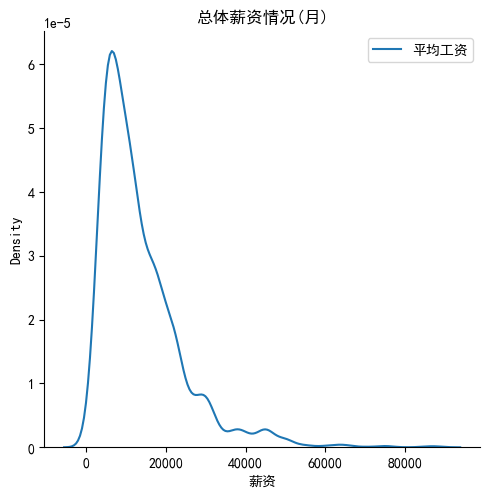

```python
#总体情况
plt.figure(figsize=(10,3))
# sns.kdeplot(data=boss,x='min')
# sns.kdeplot(data=boss,x='max')
sns.displot(data=boss,x='平均工资',kind='kde')
plt.title('总体薪资情况(月)')
plt.xlabel('薪资')
plt.legend(['平均工资'])
```

```
 [Text(0.9107676921685294, 0.616848612628748, '开发相关'),
 [Text(0.49678237754647053, 0.33646287961568067, '18.95%'),
```

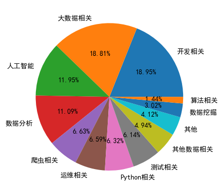

```python
#岗位类型的数量统计
# sns.countplot(data=boss,y='job')
a = boss['job'].value_counts()
plt.pie(a,labels=a.index,autopct='%1.2f%%')
```

- 根据上方饼图显示，数据分析、人工智能、大数据和软件开发的招聘信息占比都超过了10%，总共占总数的60.8%，是主要的招聘类型。

```python
x = boss.groupby(by='job')['平均工资'].mean()
x = x.sort_values(ascending=False)
x
```

```
job
数据挖掘        24124.431818
算法相关        23454.761905
大数据相关       17644.434307
人工智能        16729.166667
数据分析        15708.575851
开发相关        12497.862319
其他          10916.416667
Python相关     9129.891304
爬虫相关         8882.227979
测试相关         8619.944134
其他数据相关       8200.069444
运维相关         8062.239583
Name: 平均工资, dtype: float64
```

```
(array([ 0,  1,  2,  3,  4,  5,  6,  7,  8,  9, 10, 11]),
 [Text(0, 0, '数据挖掘'),
```

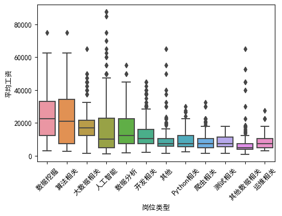

```python
#岗位和薪资
plt.figure(figsize=(6,4))
sns.boxplot(data=boss,x='job',y='平均工资',order=x.index)
plt.xlabel('岗位类型')

plt.xticks(rotation=45)
```

- 根据岗位和薪资的箱线图可以看出，数据挖掘和算法相关的岗位类型薪资都比较高属于第一梯队，但根据岗位数量占比统计，数据挖掘类型岗位占比3.02%，算法相关岗位占比1.44% 是所有类型岗位中最少的。
- 大数据、人工智能和数据分析的岗位属于薪资中的第二梯队，并且在招聘信息占比都超过了10%，就业环境最好。

```
 [Text(0.29739398736144684, 1.0694189152438158, '大专'),
 [Text(0.16343273179322756, 0.5876986831520069, '41.37%'),
```

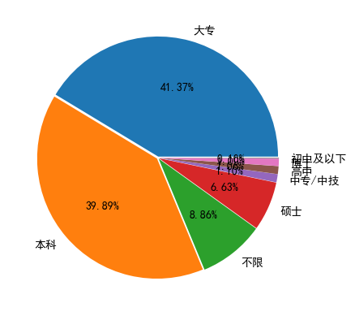

```python
# 学历分布情况
# plt.figure(figsize=(6,4))
# fig, ax = plt.subplots(1,2,figsize=(6,4))
# sns.countplot(data=boss,x='学历')
pieData = boss['学历'].value_counts()
plt.pie(pieData,labels=pieData.index,autopct='%1.2f%%',explode=[0.01,0.01,0.01,0.01,0.01,0.01,0.01,0.01])
```

- 由招聘信息的学历占比图可以看出，要求学历在本科的招聘占总招聘数量的39.89%，大专为41.37%，所以学历要求在本科和大专的招聘在大多数。

```python
boss[boss['经验'].str.contains('初中及以下')]
```

|  | 标题 | 地区 | 公司名 | 公司领域 | 薪资 | 经验 | 规模 | 福利 | 详情页 | job | city | salary | min | max | 平均工资 | 学历 |
| --- | --- | --- | --- | --- | --- | --- | --- | --- | --- | --- | --- | --- | --- | --- | --- | --- |
| 1152 | 小白月薪1w✨人力资源管理师⭐大搜数据 | 北京·朝阳区·双桥 | 环球弘文教育 | 培训机构 | 19-26K | 1年以内初中及以下 | 1000-9999人 | 餐补，员工旅游，五险一金，补充医疗保险，不定期团建，带薪年假，年终奖，零食下午茶，加班补助，... | https://www.zhipin.com/job_detail/4ab31a04a74c... | 其他数据相关 | 北京 | 12 | 19000 | 26000 | 22500.0 | 初中及以下 |
| 1433 | 人工智能培训师 | 吴忠·青铜峡市·青铜峡市中心城区 | 瑞鹿科技 | 数据服务 | 2-4K | 经验不限初中及以下 | 20-99人 | NaN | https://www.zhipin.com/job_detail/f43db7b6c8ae... | 人工智能 | 吴忠 | 12 | 2000 | 4000 | 3000.0 | 初中及以下 |
| 1830 | 测试 | 深圳·宝安区·沙井 | 科鑫源电子有限公司 | 电子/半导体/集成电路 | 5-7K | 1年以内初中及以下 | 100-499人 | NaN | https://www.zhipin.com/job_detail/60923b03c930... | 测试相关 | 深圳 | 12 | 5000 | 7000 | 6000.0 | 初中及以下 |

```
(array([0, 1, 2, 3, 4, 5, 6, 7]),
 [Text(0, 0, '博士'),
```

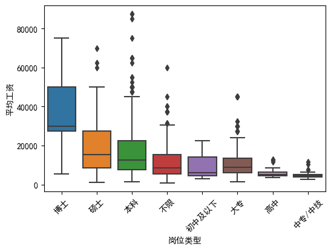

```python
xl = boss.groupby(by='学历')['平均工资'].mean()
xl = xl.sort_values(ascending=False)
#学历和薪资
plt.figure(figsize=(6,4))
sns.boxplot(data=boss,x='学历',y='平均工资',order=xl.index)
# sns.kdeplot(data=boss,x='平均工资',hue='学历')
plt.xlabel('岗位类型')
plt.xticks(rotation=45)
```

- 根据学历要求与薪资的箱线图可以看出，薪资基本与学历成正比（初中及以下只有3条数据，其中一条薪资异常高）。
- 从学历对薪资的提升上看，硕士到博士对薪资的提升最高，高中到本科次之；本科到硕士的提升较低，并且本科招聘中有部分的薪资超过了硕士甚至博士。

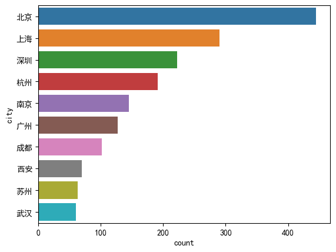

```python
# 岗位数量前10的城市
city10 = boss['city'].value_counts().head(10)
sns.countplot(data=boss[boss['city'].isin(city10.index)],y='city',order=city10.index)
```

- 根据招聘岗位数量前10的城市可以看出，热门城市大多是在长三角和珠三角等地的发达城市。

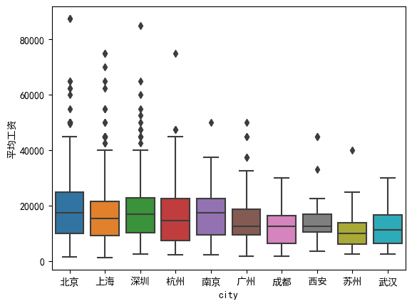

```python
# 岗位数量前10的城市的薪资情况
sns.boxplot(data=boss[boss['city'].isin(city10.index)],x='city',y='平均工资',order=city10.index)
```

- 根据岗位数量前10的城市的薪资情况，北京的平均薪资最高，上海、深圳、杭州、南京的薪资也相对较高。

从公司方面：

- 公司规模与薪资

```python
# 去重后的公司数据
df = boss.drop_duplicates(subset='公司名')
df.shape
```

[output not shown]

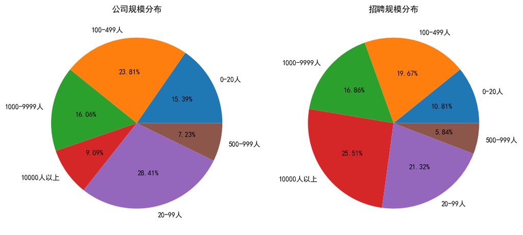

```python
#公司规模分布
# plt.figure(figsize=(12,6))
# plt.subplot(121)
# sns.countplot(data=df,x='规模',order=adc.index)
# plt.ylabel('公司数')
# plt.subplot(122)
# sns.countplot(data=boss,x='规模',order=adc.index)
# plt.ylabel('招聘数')
plt.figure(figsize=(12,6))
plt.subplot(121)
gm = df.groupby(by='规模')['公司名'].count()
plt.pie(gm,labels=gm.index,autopct='%1.2f%%')
plt.title('公司规模分布')
plt.subplot(122)
gm = boss.groupby(by='规模')['平均工资'].count()
plt.pie(gm,labels=gm.index,autopct='%1.2f%%')
plt.title('招聘规模分布')
```

- 如图所示，规模在20-99人的公司最多；规模在1000人以上的公司招聘数最多。
- 除了规模在10000人以上的公司数较少，招聘数却最多以外，公司数与招聘数成正比。

[figure not shown]

```python
# #公司规模招聘信息分布
# sns.countplot(data=boss,x='规模',order=adc.index)
# plt.ylabel('招聘数')
```

```
(array([0, 1, 2, 3, 4, 5]),
 [Text(0, 0, '10000人以上'),
```

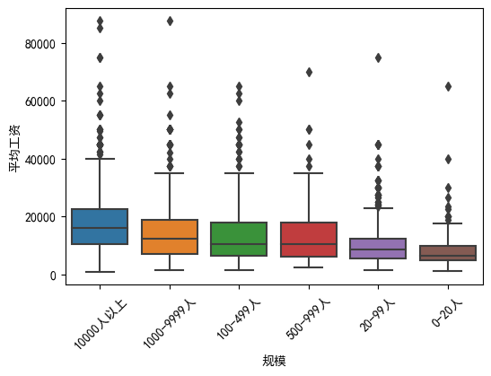

```python
# 规模与薪资
adc = boss.groupby(by='规模')['平均工资'].mean()
adc = adc.sort_values(ascending=False)
plt.figure(figsize=(6,4))
sns.boxplot(data=boss,x='规模',y='平均工资',order=adc.index)
plt.xlabel('规模')
plt.xticks(rotation=45)
```

- 根据规模与薪资的箱线图所示，基本上公司规模与薪资成正比。

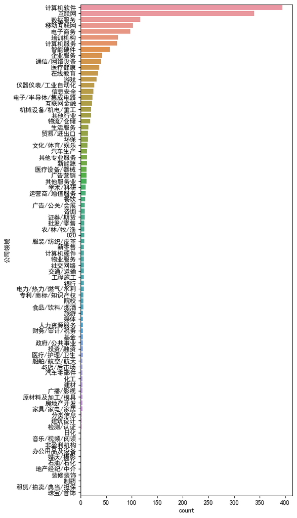

```python
#公司领域的分布
ct = df.groupby(by='公司领域')['公司名'].count()
ct = ct.sort_values(ascending=False)
plt.figure(figsize=(6,14))
sns.countplot(data=df,y='公司领域',order=ct.index)
```

- 在计算机软件和互联网领域的公司最多。

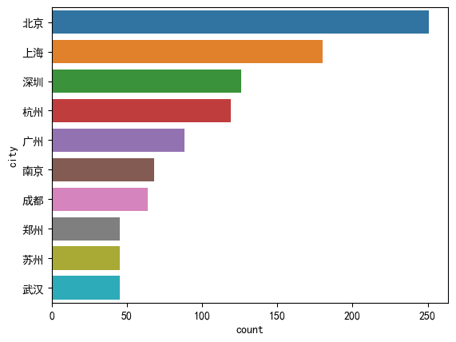

```python
# 公司地区分布
area = df['city'].value_counts().head(10)
areadata=df[df['city'].isin(area.index)]
sns.countplot(data=areadata,y='city',order=area.index)
```

福利词云图

```python
# boss['福利'][0].split('，')
word = boss['福利'].str.split('，')
word = word.tolist()
word
words = []
for i in word:
#     print(i)
    try:
        words.extend(i)
    except:
        pass
# words
dicts = {x: words.count(x) for x in set(words)}
# dicts
my_list = []
for key,val in dicts.items():
    my_list.append((key,val))
# print(my_list)

from pyecharts import options as opts
from pyecharts.charts import WordCloud

words = my_list

c = (
    WordCloud()
    .add(
        "",
        words,
        word_size_range=[20, 100],
        textstyle_opts=opts.TextStyleOpts(font_family="cursive"),
    )
    .set_global_opts(title_opts=opts.TitleOpts(title="福利词云图"))
)
c.render_notebook()
```

[output not shown]